# R section nationality analysis

Adam Finnemann

September 24, 2017

Question: How many nationas are there in the League over time:

Reading in list of nationations in the League. Data from wikipedia

```r
members <- read.csv("membership_overview.csv", sep = ";", na.strings = c("NA", ""))
```

Data frame showing number of member states in the League

```r
per_year <- sapply(members, function(x) sum(!is.na(x)))

year <- str_replace_all(names(per_year), "X","")

per_year <- data.frame(per_year, year) %>%
  mutate(year = as.Date(paste0(year, '-01-01')))
per_year
```

```
##    per_year       year
## 1        49 1920-01-01
## 2        52 1921-01-01
## 3        53 1922-01-01
## 4        55 1923-01-01
## 5        56 1924-01-01
## 6        56 1925-01-01
## 7        56 1926-01-01
## 8        55 1927-01-01
## 9        55 1928-01-01
## 10       55 1929-01-01
## 11       55 1930-01-01
## 12       56 1931-01-01
## 13       58 1932-01-01
## 14       58 1933-01-01
## 15       59 1934-01-01
## 16       58 1935-01-01
## 17       57 1936-01-01
## 18       54 1937-01-01
## 19       51 1938-01-01
## 20       49 1939-01-01
## 21       43 1940-01-01
## 22       39 1941-01-01
## 23       39 1942-01-01
## 24       38 1943-01-01
## 25       38 1944-01-01
## 26       38 1945-01-01
## 27       38 1946-01-01
## 28       38 1947-01-01
## 29       38 1948-01-01
```

plotting number of nations in the League

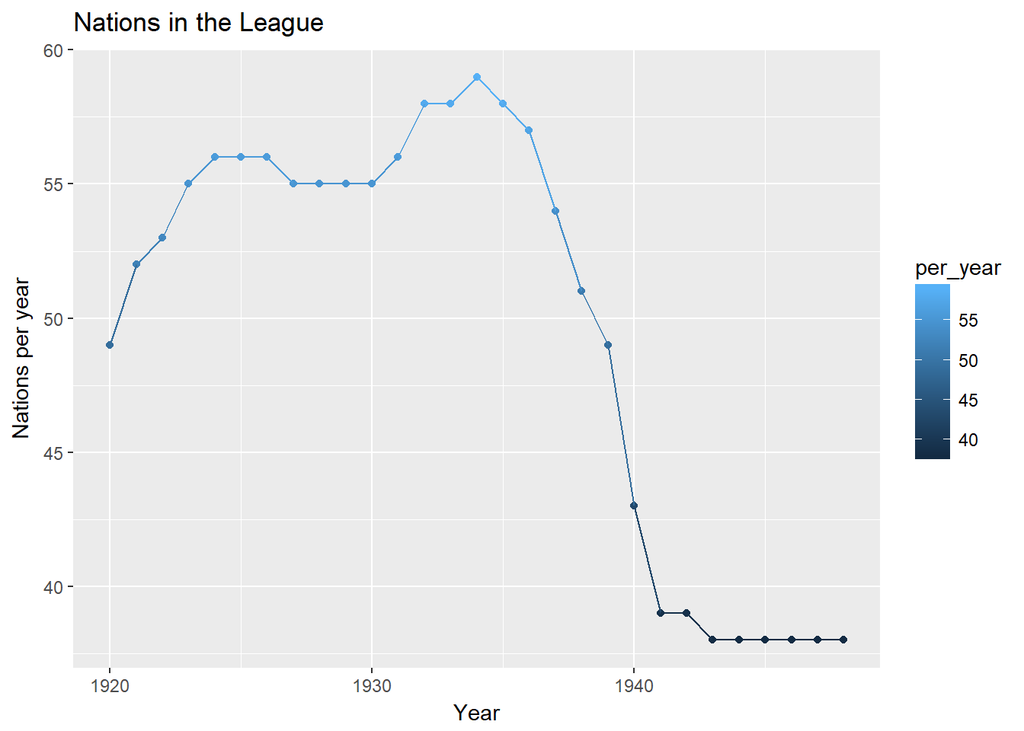

```r
per_year %>%
  ggplot(aes(year, per_year, color = per_year)) +
  geom_point() +
  geom_line() +
  labs(x = "Year", y = "Nations per year", title = "Nations in the League")
```

Question: How many nations have at lease one person in the Section over time:

```r
da <- read.csv(list.files(pattern = "reve"))

section_worker <- da %>%
  filter(str_detect(da$fname, "Section")) %>%
  filter(fname != "Secretary of Section")
```

Aligning British and English personnel

```r
section_worker <- section_worker %>%
  mutate( nationality = recode(nationality, "English" = "British"))
```

Creating employment df

```r
source("employment_interval_function.R")

nat_df <- section_worker %>%
  mutate(pname = nationality)


mdl_df <- nat_df %>%
  select(pname, fname_code,begin_date, end_date) %>%
  mutate(begin_date = as.Date(begin_date),
         end_date = as.Date(end_date))



setDT(mdl_df)[
  # right join with sequence of monthly intervals
  .(mseq = seq(as.Date("1944-01-01"), length.out = 4L, by = "1 month")),
  # using non-equi join conditions
  on = .(begin_date <= mseq, end_date >= mseq)][
    # reshape from wide to long format,
    # show rank (concatenate in case of multiple ranks)
    , dcast(unique(.SD), pname ~ end_date, toString, value.var = "fname_code")]
```

```
##             pname 1944-01-01 1944-02-01 1944-03-01 1944-04-01
##  1:    Australian          8          8          8          8
##  2:      Austrian          8          8          8          8
##  3:       British       8, 6       8, 6       8, 6       8, 6
##  4:         Dutch          8          8          8          8
##  5:      Estonian          8          8          8          8
##  6:        French       9, 8       9, 8       9, 8       9, 8
##  7:        Indian          8          8          8          8
##  8:         Irish          8          8          8          8
##  9:       Latvian          8          8          8          8
## 10: New_Zealander          8          8          8          8
## 11:     Norwegian          8          8          8          8
## 12:        Polish          8          8          8          8
## 13:       Swedish       9, 8       9, 8       9, 8       9, 8
## 14:       Turkish          8          8          8          8
## 15:      Yugoslav          9          9          9          9
```

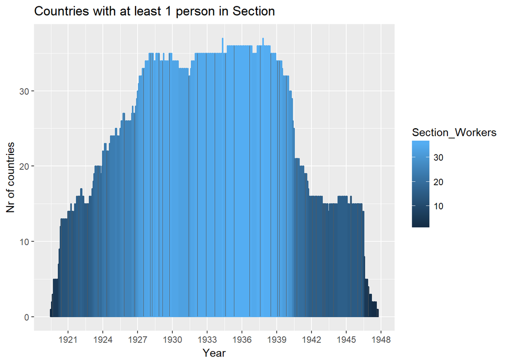

```r
result <- setDT(mdl_df)[
  .(mseq = seq(as.Date("1919-01-01"), as.Date("1948-12-30"), by = "1 month")),
  on = .(begin_date <= mseq, end_date >= mseq), nomatch = 0L, allow.cartesian = TRUE][
    , dcast(unique(.SD), pname ~ end_date, toString, value.var = "fname_code")]


removed <- result[,-1]

time_section <- matrix(nrow = (ncol(removed)), ncol = 1)

for (i in 1:(nrow(time_section))){
  time_section[i] = sum(removed[,i, with = F] != "")
}


dates <- as.character(colnames(removed))

plot.df <- cbind(time_section,dates) %>%
  as.data.frame() %>%
  mutate(dates = as.Date(dates),
         V1 = as.numeric(as.character(V1))) %>%
  rename(Section_Workers = V1)

plot <- plot.df %>%
  ggplot(aes(dates, Section_Workers, color = Section_Workers )) +
  geom_col()+
  labs(x = "Year", y ="Nr of countries", titles = "Countries with at least 1 person in Section")+
  scale_x_date(date_breaks = "3 year", date_labels = "%Y")


plot
```

Next: Plot with nr. of nations in League and nations with Workers in section. Assumptions: Nations are represented as being part of the League from januar 1. of the year they joined. Period visualized is 1920-01-01 to 1947-10-01 Number of workers in section is calculated for each Month

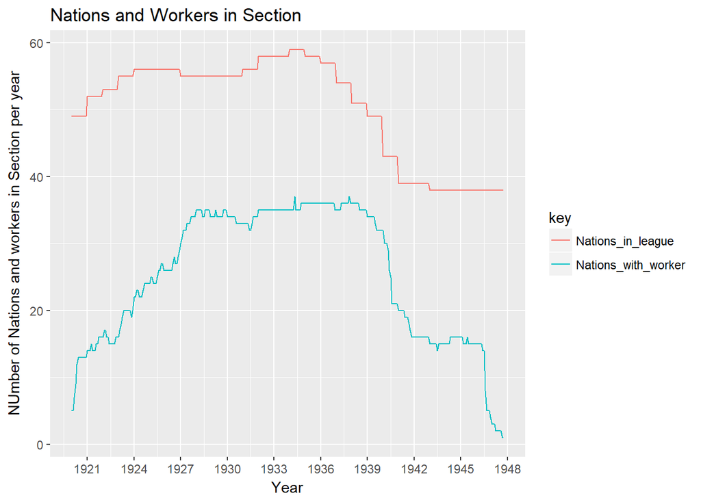

```r
per_month = per_year[rep(seq_len(nrow(per_year)), each=12),]


plot.df <- plot.df[-c(1:6),]
per_month = per_month[1:334,]
plot.df$Nations_in_League <- per_month$per_year

colnames(plot.df) <- c("Nations_with_worker","Years","Nations_in_league")

long_plot <- gather(plot.df, key, value, Nations_in_league,Nations_with_worker)



long_plot %>%
  ggplot(aes(x = Years, y = value, color = key)) +
 # geom_point() +
  geom_line() +
  labs(x = "Year", y = "NUmber of Nations and workers in Section per year", title = "Nations and Workers in Section")+
  scale_x_date(date_labels = "%Y", date_breaks = "3 years")
```

Next: A tentative plot of how the Section workers are distributed among nations. For the sake over clarity, only data points with more than 10 people in the Section at that given time is kept.

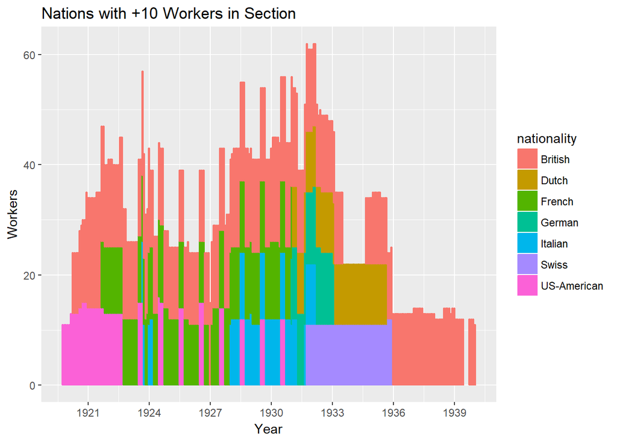

```r
mdl_df <- section_worker %>%
  select(pname, fname_code,begin_date, end_date) %>%
  mutate(begin_date = as.Date(begin_date),
         end_date = as.Date(end_date))



result <- setDT(mdl_df)[
  .(mseq = seq(as.Date("1919-01-01"), as.Date("1948-12-30"), by = "1 month")),
  on = .(begin_date <= mseq, end_date >= mseq), nomatch = 0L, allow.cartesian = TRUE][
    , dcast(unique(.SD), pname ~ end_date, toString, value.var = "fname_code")]

result_nats <- merge(result, section_worker[,c(8,20)], by = "pname")

result_nats <- result_nats[,-1]


#A MIRACLE!!!
nation_workers <- result_nats %>%
  group_by(nationality) %>%
  summarise_all(function(x) sum(x != ""))

long_df <- gather(nation_workers, key, value, `1919-07-01`:`1947-10-01`) %>%
  mutate(key = as.Date(key))





 long_df %>%
  filter(value > 10) %>%
  ggplot(aes(x = key, y = value, fill = nationality, color = nationality)) +
  geom_col() +
  scale_x_date(date_breaks = "3 year", date_labels = "%Y") +
  labs(x = "Year", y ="Workers", titles = "Nations with +10 Workers in Section")
```

for 8 workers:

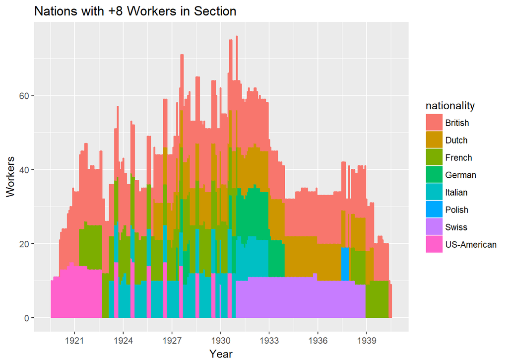

```r
long_df %>%
  filter(value > 8) %>%
  ggplot(aes(x = key, y = value, fill = nationality, color = nationality)) +
  geom_col() +
  scale_x_date(date_breaks = "3 year", date_labels = "%Y") +
  labs(x = "Year", y ="Workers", titles = "Nations with +8 Workers in Section")
```

Next: Running same analysis for Section workers with oname = Information Section. In the final plot only data points for each country with more than 1 person in the Information Section is kept.

```r
plot <- filter(section_worker,oname == "Information Section")


mdl_df <- plot %>%
  select(pname, fname_code,begin_date, end_date) %>%
  mutate(begin_date = as.Date(begin_date),
         end_date = as.Date(end_date))



setDT(mdl_df)[
  # right join with sequence of monthly intervals
  .(mseq = seq(as.Date("1944-01-01"), length.out = 4L, by = "1 month")),
  # using non-equi join conditions
  on = .(begin_date <= mseq, end_date >= mseq)][
    # reshape from wide to long format,
    # show rank (concatenate in case of multiple ranks)
    , dcast(unique(.SD), pname ~ end_date, toString, value.var = "fname_code")]
```

```
##    pname 1944-01-01 1944-02-01 1944-03-01 1944-04-01
## 1:    NA         NA         NA         NA         NA
```

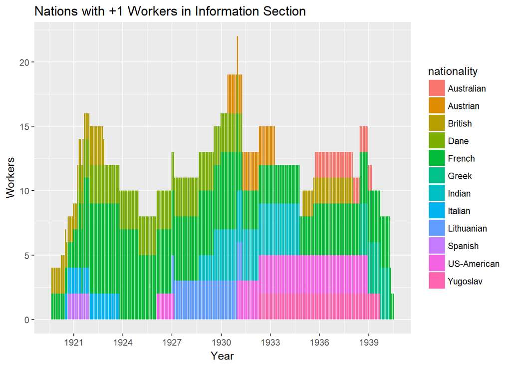

```r
result <- setDT(mdl_df)[
  .(mseq = seq(as.Date("1919-01-01"), as.Date("1948-12-30"), by = "1 month")),
  on = .(begin_date <= mseq, end_date >= mseq), nomatch = 0L, allow.cartesian = TRUE][
    , dcast(unique(.SD), pname ~ end_date, toString, value.var = "fname_code")]

result_nats <- merge(result, section_worker[,c(8,20)], by = "pname")

result_nats <- result_nats[,-1]


#A MIRACLE!!!
nation_workers <- result_nats %>%
  group_by(nationality) %>%
  summarise_all(function(x) sum(x != ""))


long_df <- gather(nation_workers, key, value, `1919-09-01`:`1942-12-01`) %>%
  mutate(key = as.Date(key))





 long_df %>%
  filter(value > 1) %>%
  ggplot(aes(x = key, y = value, fill = nationality)) +
  geom_col() +
  scale_x_date(date_breaks = "3 year", date_labels = "%Y") +
  labs(x = "Year", y ="Workers", titles = "Nations with +1 Workers in Information Section")
```

Employment/nationality plot for larger section, data points > 10 kept:

[figure not shown]

```r
long_df %>%
  filter(value > 10) %>%
  ggplot(aes(x = key, y = value, fill = nationality, color = nationality)) +
  geom_col() +
  scale_x_date(date_breaks = "3 year", date_labels = "%Y") +
  labs(x = "Year", y ="Workers", titles = "Nations with +10 Workers in Information Section")
```

Investigating middle period: 1927-1939.

```r
library(anytime)
```

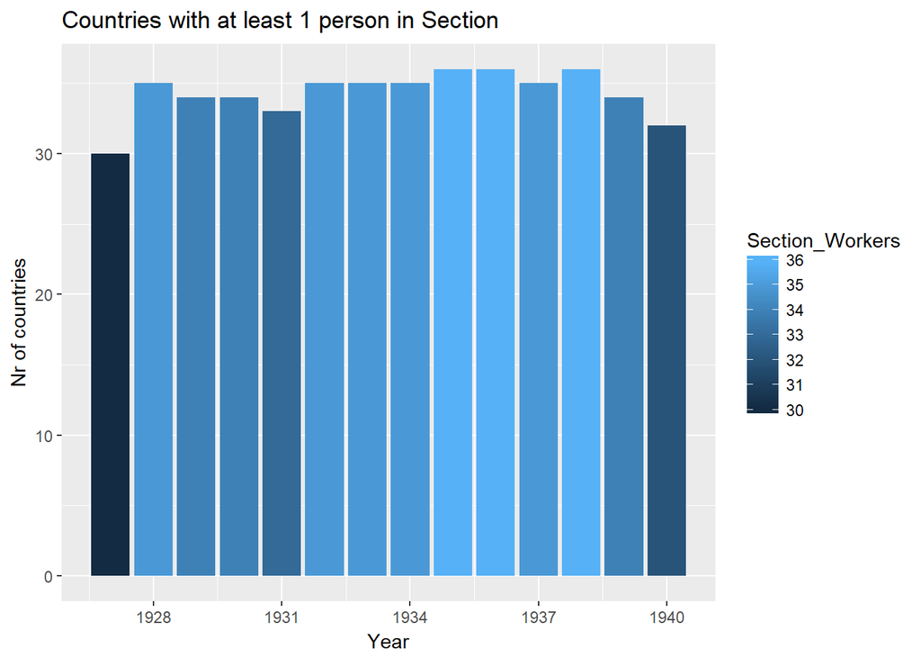

```r
#equating contracts during year with a contract at 01-01-year
standard_date <- section_worker %>%
  mutate(begin_date = as.Date(paste(begin_on_year,"-01-01", sep = "")),
         end_date = as.Date(paste(end_on_year, "-01-01", sep = "")))


mdl_df <- nat_df %>%
  select(nationality, fname_code,begin_date, end_date) %>%
  mutate(begin_date = as.Date(begin_date),
         end_date = as.Date(end_date))


result <- setDT(mdl_df)[
  .(mseq = seq(as.Date("1927-01-01"), as.Date("1940-01-01"), by = "1 year")),
  on = .(begin_date <= mseq, end_date >= mseq), nomatch = 0L, allow.cartesian = TRUE][
    , dcast(unique(.SD), nationality ~ end_date, toString, value.var = "fname_code")]


removed <- result[,-1]

time_section <- matrix(nrow = (ncol(removed)), ncol = 1)

for (i in 1:(nrow(time_section))){
  time_section[i] = sum(removed[,i, with = F] != "")
}


dates <- as.character(colnames(removed))

plot.df <- cbind(time_section,dates) %>%
  as.data.frame() %>%
  mutate(dates = as.Date(dates),
         V1 = as.numeric(as.character(V1))) %>%
  rename(Section_Workers = V1)

plot <- plot.df %>%
  ggplot(aes(dates, Section_Workers, fill = Section_Workers )) +
  geom_col()+
  labs(x = "Year", y ="Nr of countries", titles = "Countries with at least 1 person in Section")+
  scale_x_date(date_breaks = "3 year", date_labels = "%Y")


plot
```

calculating number of countries constantly represented

```r
result <- result %>%
  mutate(constant = apply(result,1, function(x) sum(x == "")==0)) %>% #true if country have a no missing
  select(constant, everything())

sum(result$constant)
```

```
## [1] 21
```

which contries aren’t and are constantly present

```r
lacking_presence <- result %>%
  filter(constant == F)

constant_presence <- result %>%
  filter(constant == T)

#write.csv(constant_presence, "constant_presence.csv")
```

Same analysis, including directors

```r
directors <- da %>%
  filter(str_detect(da$fname, "Director")) %>%
  select(pname) %>%
  unique() %>%
  as.list()


directors <- da %>%
filter(da$pname %in% directors$pname) %>%
  mutate(nationality = as.factor(nationality))


direc_and_sec <- rbind(directors, section_worker)

direc_and_sec <- direc_and_sec %>%
mutate(nationality = recode(nationality, "Italian,Italian" = "Italian"))
```

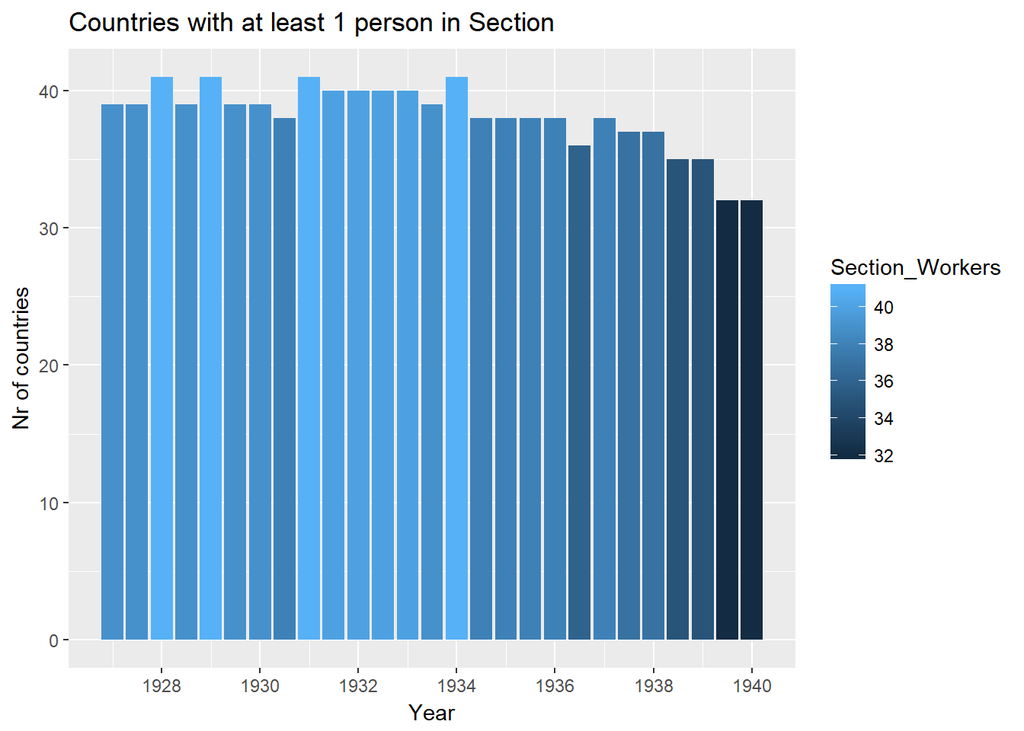

```r
nat_df <- direc_and_sec %>%
  mutate(pname = nationality,
         begin_date <- as.Date(begin_date),
         end_date <- as.Date(end_date),
         #equating contracts during year with a contract at 01-01-year
         begin_date = as.Date(paste(begin_on_year,"-01-01", sep = "")),
         end_date = as.Date(paste(end_on_year, "-01-01", sep = "")))


mdl_df <- nat_df %>%
  select(pname, fname_code,begin_date, end_date) %>%
  mutate(begin_date = as.Date(begin_date),
         end_date = as.Date(end_date))


result <- setDT(mdl_df)[
  .(mseq = seq(as.Date("1927-01-01"), as.Date("1940-01-01"), by = "6 month")),
  on = .(begin_date <= mseq, end_date >= mseq), nomatch = 0L, allow.cartesian = TRUE][
    , dcast(unique(.SD), pname ~ end_date, toString, value.var = "fname_code")]


removed <- result[,-1]

time_section <- matrix(nrow = (ncol(removed)), ncol = 1)

for (i in 1:(nrow(time_section))){
  time_section[i] = sum(removed[,i, with = F] != "")
}


dates <- as.character(colnames(removed))

plot.df <- cbind(time_section,dates) %>%
  as.data.frame() %>%
  mutate(dates = as.Date(dates),
         V1 = as.numeric(as.character(V1))) %>%
  rename(Section_Workers = V1)

plot <- plot.df %>%
  ggplot(aes(dates, Section_Workers, fill = Section_Workers )) +
  geom_col()+
  labs(x = "Year", y ="Nr of countries", titles = "Countries with at least 1 person in Section")+
  scale_x_date(date_breaks = "2 year", date_labels = "%Y")


plot
```

```r
result <- result %>%
  mutate(constant = apply(result,1, function(x) sum(x == "")==0)) %>% #true if country have a no missing
  select(constant, everything())

sum(result$constant)
```

```
## [1] 25
```

which contries aren’t constantly present

```r
lacking_presence <- result %>%
  filter(constant == F)

constant_presence <- result %>%
  filter(constant == T)

write.csv(lacking_presence, "lacking_presence_w_director.csv")
```

Some participants are missing. Only people who have been present at the 01-01 or 07-01 of a year is counted. Secondly, the following data points have missing data points

```r
leftout_contracts <- standard_date %>%
  filter( is.na(begin_date) | is.na(end_date))

length(unique(leftout_contracts$pname))
```

```
## [1] 12
```